# Estudios de Informática, Multimedia y Telecomunicaciones

### 7.2.3 Adequació del model

#### 7.2.3.1 Normalitat

Mostrarem el plot Q-Q i posteriorment un test de Lilliefors

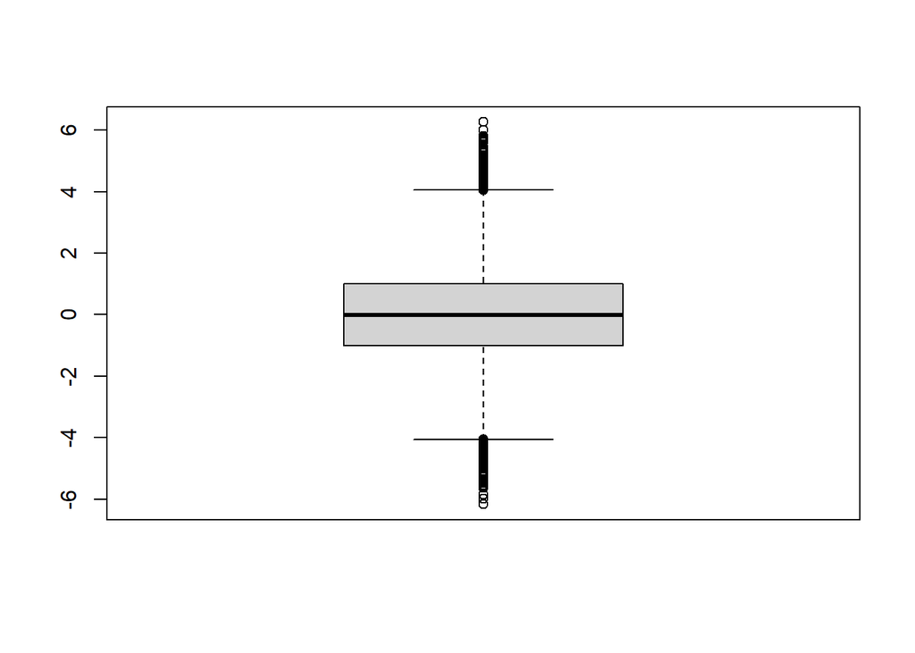

```r
boxplot(twofactors.model$residuals)
```

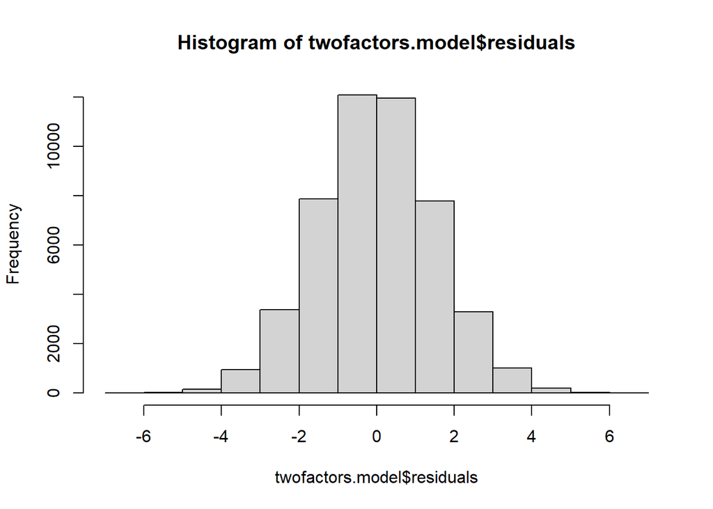

```r
hist(twofactors.model$residuals)
```

Tant amb l’histograma com amb el boxplot podem intuïr normalitat en els residus del model.

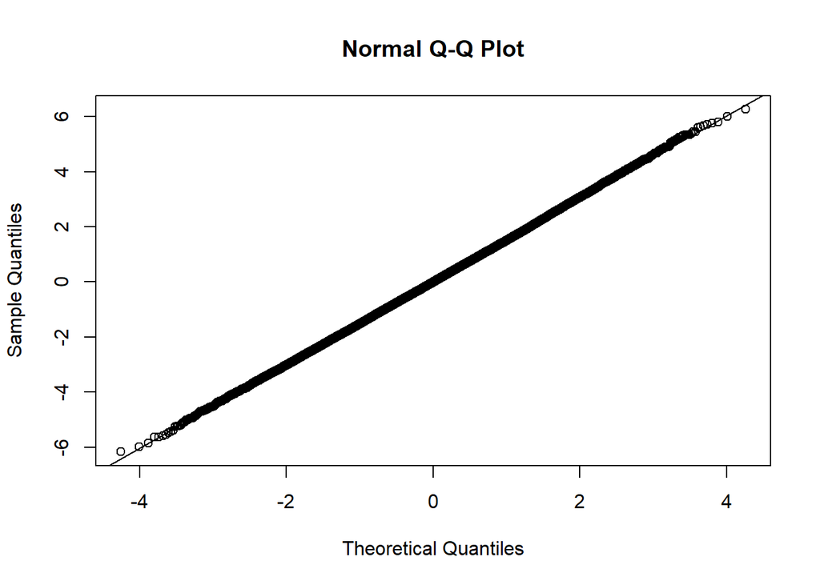

```r
qqnorm(twofactors.model$residuals)
qqline(twofactors.model$residuals)
```

La prova de normalitat de Q-Q plot ens ho confirma visualment però ara farem un test per a concloure el que ja sabem.

```r
lillie.test(twofactors.model$residuals)
```

```
##
##  Lilliefors (Kolmogorov-Smirnov) normality test
##
## data:  twofactors.model$residuals
## D = 0.0032726, p-value = 0.2347
```

Amb valor per sobre de 0.05 podem dir que les dades segueixen una distribució normal.

#### 7.2.3.2 Homoscedasticitat

Fem un gràfic de residus vs. valors ajustat.

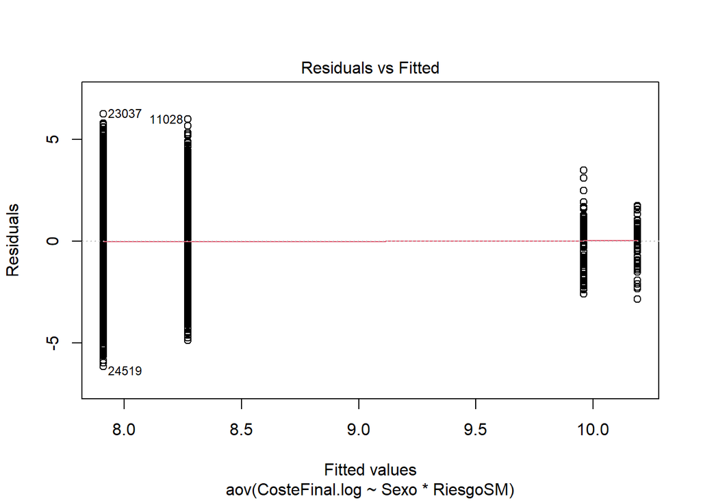

```r
plot(twofactors.model, which = 1)
```

Observem quate líneas verticals de punts que estan situades en les mitjanes de cada grup que corresponen als valors ajustats de les observacions. La disposició dels residus mostra una dispersió no molt semblant. Sembla que tenim heterocedasticitat.

```r
condition <- with(claimNet, interaction(RiesgoSM, Sexo))
bartlett.test(CosteFinal.log ~ condition, data = claimNet)
```

```
##
##  Bartlett test of homogeneity of variances
##
## data:  CosteFinal.log by condition
## Bartlett's K-squared = 185.26, df = 3, p-value < 2.2e-16
```

Amb un p-valor < 0.05, rebutjem la hipòtesi nul·la i no acceptem que les variàncies són iguals com ha ens havia semblat en el plot.

## 7.3 Interpretació dels resultats

Hem determinat amb les proves que tant RiesgoSM com Sexo són factors significatius en la resposta de CosteFinal. En canvi, la interacció no ho és.

El model no ajusta molt bé, el motiu pot venir donat perquè tenim heterocedasticitat en els residus. Uns posible sol·lució seria variar la respost per a obtenir una anova on els errors siguin mínims.

# 8 Conclusions

## 8.1 Estudi

Durant l’exercici hem realitzat un estudi per determinar com impacten algunes variables sobre el cost final de les indemnitzacions per baixa laboral atorgades per una companyia d’assegurançes.

## 8.2 Preparació de les dades

Excepte alguna transformació, no hem realitzat gaires canvis. Hem canviat els noms, transformació de classes, hem creat les variables Tiempo, Clasificacion i RiesgoSM i finalment hem eliminat els valors absents.

En els analisis visuals que hem fet tenim un augment en el RiesgoSM dels homes respecte les dones, si estan casats respecte els solters i sobretot si tenen una malaltia mental.

En aquest apartat hem vist que la variable CostFinal segueix una distribució lognormal.

## 8.3 Estadística inferencial

Hem alculat un interval de confiança de la variable CosteFinal. Hem conclós que la mitjana de CosteFinal amb un nivell de confiança de 95% és troba entre els valors 9281.64 i 10127.52.

En el cotrast d’hipòtesi per saber si les dones perceben el mateix que els homes més 1000, hem conclós que efectivament és així.

## 8.4 Model regressió lineal

En el model de regressió lineal hem obtingut un model que no ajusta molt bé. Els residus no segueixen una distribució normal.

## 8.5 Model regressió logística

En el model logístic les variables significatives han estat sobretot, Edad, Sexo, Estado, Dependientes, Salario, Jornada, DiasSemana i log(CosteInicio). Després amb els OR, per exemple la variable Salario no ho era pas.

El model ens prediu molt millor els casos en els quals el preu final és superior al inicial.

## 8.6 Anova

Amb anova hem conclós que el factor Clasificacion és significatiu, es a dir, el temps que passa des de que és produeix el sinistre fins que s’obre el expedient influeix en el cost final.

De totes formes el model té les seves limitacions i no ajusta molt bé, segurament perquè tenim heterocedasticitat en els residus.

Amb dos factors, hem comprovat si impactan en el cost final el sexe i el fet de tenir malaltia mental. En els dos casos hem vist que sí. En canvi, la combinació dels dos factors no afecta al resultat.